# 线性回归简介 cqu.ai 第一次沙龙分享讲义

muzhi

2017/12/12

本文简单介绍线性回归的基本原理，从线性代数，机器学习的角度看待这个问题。本文严重参考了MIT线性代数和斯坦福机器学习。讲义比较简单，具体听主讲人讲解。

## 从线性代数看待这个问题

### 投影

要理解最小二乘的线代形式可以从投影的角度入手。

已知两个向量，不平行
$$a \\ b$$
但是我们还是想求一个最优的x，使
$$ax=b$$
设P为投影矩阵
$$Pb=\widehat{b}\\
a\widehat{x} = \widehat{b}\\
a\widehat{x} = P b\\
e = b-a\widehat{x}\\a^Te= 0$$

可以求得投影矩阵
$$P = \frac{aa^T}{a^Ta}$$

### 最小二乘法

最小二乘法与投影的角度一样的，只不过是用在了矩阵上。 已知矩阵
$$A$$
和向量
$$b$$
求解
$$Ax = b$$
，但是b不在A的列空间内，所以x无解，但是可以求出一个最优的
$$\widehat{x}$$
以及 投影矩阵
$$P$$
使得
$$Pb$$
在
$$A$$
的列空间内，
$$\widehat{x}$$
即为参数的最佳估计。

根据投影的套路可以得：
$$A\widehat{x}=\widehat{P}b$$
e与A垂直
$$e=b-\widehat{P}b\\A^Te=0$$
求得
$$P = A(A^TA)^{-1}A^T\\
\widehat{x}=(A^TA)^{-1}A^Tb$$

## 从优化的角度看待这个问题

线性回归的非线代算法的构成主要可以分成两个模块，一个是代价函数(costfunction)，另一个是优化方法。 线性回归的代价函数很简单，但是一般代价函数需要构造成凸函数。这里我直接写了一个基于梯度下降的线性回归，到时候细讲。

### 求偏导，求极值

只要代价函数是凸函数，那么对其求偏导等于零时求的的x即为，最优解。可以发现求导得到表达式就是从线代角度得到的表达式。

### 梯度下降

梯度下降是机器学习中常用的，基础的优化算法。这里使用`R`语言从基础写一个基于最小二乘法的线性回归模型，了解梯度下降法的基本原理。

```r
A <- matrix(c(1,1,1,1,2,3), nrow = 3, ncol = 2)
b <- matrix(c(1,2,2), nrow = 3, ncol = 1)
##初始化参数x
x <- matrix(0, nrow = 2, ncol = 1)

##定义函数
f <- function(A, x){
  return(A%*%x)
}
##定义代价函数
costfun <- function(b,bhat){

  return(sum((b - bhat)^2))
}
###建立优化函数，来优化线性模型
linear_optimal <- function(b, A, x, learn_ratio = 0.1){
  bhat <- f(A,x)
  cost <- costfun(b,bhat)
  e <- 1
  cost_record <- cost
  while (e >= 1e-10) {
    dx1 <- sum(-(b - bhat))
    dx2 <- -A[,2]%*%(b-bhat)

    x[1] <- x[1] - learn_ratio*dx1
    x[2] <- x[2] - learn_ratio*dx2

    bhat <- f(A,x)
    cost_temp <- costfun(b,bhat)
    e <- abs(cost - cost_temp)
    cost <- cost_temp
    cost_record <- c(cost_record,cost)
    #print(x)

  }
  return(list(bhat = bhat, cost = cost,x = x, cost_record = cost_record))
}
```

使用 `liner_optimal`自建函数来试一下

```r
mylinear <-  linear_optimal(b, A, x)

##估计模型参数
mylinear$x
```

```
##           [,1]
## [1,] 0.6666130
## [2,] 0.5000236
```

查看cost的每次迭代情况

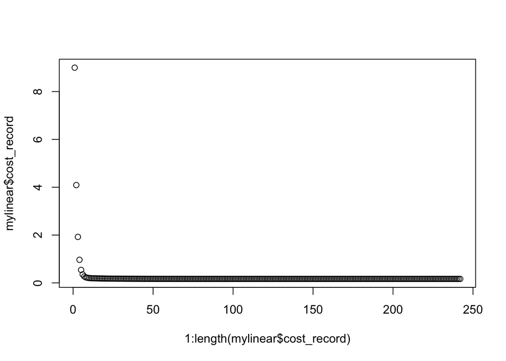

```r
plot(1:length(mylinear$cost_record),mylinear$cost_record)
```

利用R的自带下行回归检验我们估计的是否正确

```r
d <- data.frame(x = c(1,2,3),y = c(1,2,2) )

l <- lm(y~x, data = d)

##自带函数估计值
l$coefficients
```

```
## (Intercept)           x
##   0.6666667   0.5000000
```

```r
##自建函数的估计值
mylinear$x
```

```
##           [,1]
## [1,] 0.6666130
## [2,] 0.5000236
```

结果很接近，几乎完全一致。